# Reproducible Research: Peer Assessment 1

## Loading and preprocessing the data

Here we will load the libraries and read in the dataset. We will then convert the date from string to date.

```r
library(dplyr)
library(lattice)

activity = read.csv("activity.csv",stringsAsFactors = F)
activity$date = as.Date(activity$date,"%Y-%m-%d")
```

## What is mean total number of steps taken per day?

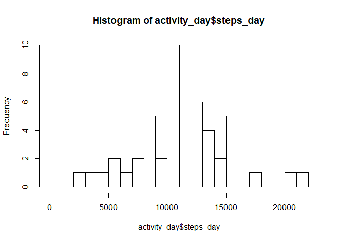

```r
activity_day = activity %>%
  group_by(date) %>%
  summarise(steps_day = sum(steps,na.rm = T), steps_day_avg = mean(steps,na.rm = T))

hist(activity_day$steps_day, breaks = 20)
```

```r
summary(activity_day)
```

```
##       date              steps_day     steps_day_avg
##  Min.   :2012-10-01   Min.   :    0   Min.   : 0.1424
##  1st Qu.:2012-10-16   1st Qu.: 6778   1st Qu.:30.6979
##  Median :2012-10-31   Median :10395   Median :37.3785
##  Mean   :2012-10-31   Mean   : 9354   Mean   :37.3826
##  3rd Qu.:2012-11-15   3rd Qu.:12811   3rd Qu.:46.1597
##  Max.   :2012-11-30   Max.   :21194   Max.   :73.5903
##                                       NA's   :8
```

## What is the average daily activity pattern?

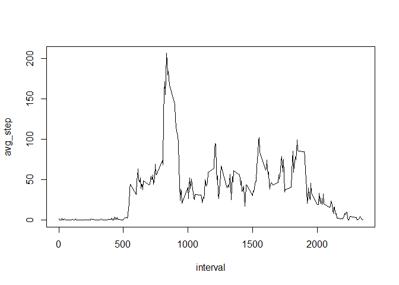

```r
activity_int = activity%>%
  group_by(interval)%>%
  summarise(avg_step = mean(steps, na.rm = T))

max_step = activity_int[which.max(activity_int$avg_step),]

with(activity_int, plot(interval,avg_step,type = "l"))
```

```r
sum(is.na(activity$steps))
```

```
## [1] 2304
```

We can see that there is a significant number of missing values in this dataset.

```r
activity_impute = activity %>%
  left_join(activity_int) %>%
  mutate(steps_narm = ifelse(is.na(steps) == TRUE, avg_step,steps))
```

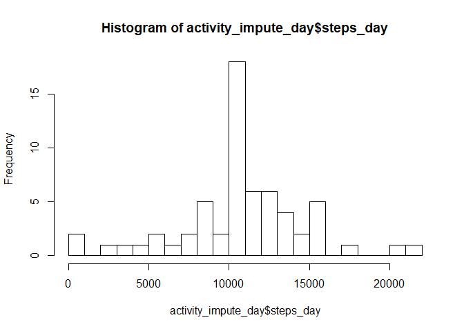

```r
activity_impute_day = activity_impute %>%
  group_by(date)%>%
  summarise(steps_day = sum(steps_narm, na.rm = T))

hist(activity_impute_day$steps_day,breaks = 20)
```

```r
summary(activity_impute_day)
```

```
##       date              steps_day
##  Min.   :2012-10-01   Min.   :   41
##  1st Qu.:2012-10-16   1st Qu.: 9819
##  Median :2012-10-31   Median :10766
##  Mean   :2012-10-31   Mean   :10766
##  3rd Qu.:2012-11-15   3rd Qu.:12811
##  Max.   :2012-11-30   Max.   :21194
```

We first calculate the average number of steps based on the interval (done in a previous step and saved as activity int). Then, we join that to the originial activity table, and create a new column where we replace the na value with the average value, but leave it as it is if it’s not na.

Using our newly imputed values, we group by the date and summarise the total steps taken by day. As we can see, the large number of 0 values were placed into the median/mean bucket.

## Are there differences in activity patterns between weekdays and weekends?

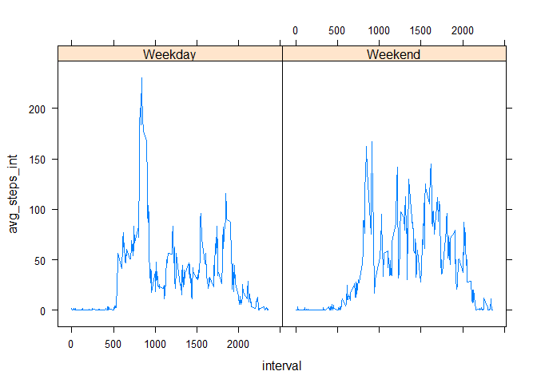

```r
activity_weekday = activity_impute%>%
  mutate(weekday = weekdays(date)) %>%
  mutate(weekday_ind = ifelse(weekday %in% c("Saturday","Sunday"),"Weekend","Weekday"))%>%
  group_by(interval,weekday_ind)%>%
  summarise(avg_steps_int = mean(steps_narm))

xyplot(avg_steps_int ~ interval | weekday_ind, data = activity_weekday, type = "l")
```